# R Notebook

## 1.Preparation

All datasets have been merged into “ER_DRUG_DEATH_ACS.csv”. Jump to “2. Clean and Standardize”.

### 1.2 Data Preparation

```r
file_path <- "../Data/ER_opioid_2016_2019_cleaned.csv"
if (!file.exists(file_path)) {
  stop("File not found: Data/ER_opioid_2016_2019_cleaned.csv")
}
er_data <- read_csv(file_path, show_col_types = FALSE)

# Keep a subset of North / Central AL (as in your script)
keep_cnty <- toupper(c(
  "Lauderdale","Limestone","Madison","Jackson","Colbert","Franklin",
  "Lawrence","Morgan","Marshall","Dekalb","Marion","Winston",
  "Cullman","Blount","Etowah","Cherokee","Lamar","Fayette",
  "Walker","Jefferson","St. Clair","Pickens","Tuscaloosa","Shelby"
))

er_data <- er_data |>
  mutate(County = toupper(County),
         Date = as.Date(Date)) |>
  filter(County %in% keep_cnty)


# Read Data_ARCOS and clean for next process
Data_ARCOS <- read_csv("../BigData/ARCOS_AL_2016_2019_cleaned.csv")

Data_ARCOS_filted <- Data_ARCOS%>%
  filter(drug %in% c("OXYCODONE", "HYDROCODONE", "BUPRENORPHINE", "METHADONE"))%>%
  filter(county %in% toupper(c(
    "Lauderdale", "Limestone", "Madison", "Jackson", "Colbert", "Franklin",
    "Lawrence", "Morgan", "Marshall", "Dekalb", "Marion", "Winston",
    "Cullman", "Blount", "Etowah", "Cherokee", "Lamar", "Fayette",
    "Walker", "Jefferson", "St. Clair", "Pickens", "Tuscaloosa", "Shelby"
  ))
  )%>%
  #mutate(mme = mme/1000000)%>%
  mutate(Date = mdy(date))%>%
  mutate(County = toupper(county))

arcos_wide_mme <- Data_ARCOS_filted %>%
  pivot_wider(
    id_cols    = c(County, Date),
    names_from = drug,
    values_from= mme,
    values_fill = 0
  )

df_er_drug <- left_join(
  er_data,
  arcos_wide_mme,
  by = c("County", "Date")
)
```

### 1.3 ER and Drugs Annually aggregation + covariates

```r
# Presence at daily level
df_er_drug <- df_er_drug |>
  mutate(
    year = year(Date),
    presence = if_else(Count > 0, 1L, 0L)
  )

# Aggregate to county × year
df_er_drug_annual <- df_er_drug %>%
  group_by(County, year) %>%
  summarise(
    # population for the year (choose one: mean/first/median)
    pop_year = first(pop),

    # ER annual
    ER_annual = sum(Count, na.rm = TRUE),

    # Drug annual
    OXYCODONE_annual     = sum(OXYCODONE,     na.rm = TRUE),
    HYDROCODONE_annual   = sum(HYDROCODONE,   na.rm = TRUE),
    BUPRENORPHINE_annual = sum(BUPRENORPHINE, na.rm = TRUE),
    METHADONE_annual     = sum(METHADONE,     na.rm = TRUE),

    presence = as.integer(sum(Count, na.rm = TRUE) > 0),
    .groups = "drop"
  ) %>%
  mutate(
    # per-capita (proportion) and per 100k (common epidemiology scale)
    ER_annual_percapita           = ER_annual / pop_year,
    ER_annual_per100k             = ER_annual_percapita * 1e5,

    OXYCODONE_annual_percapita    = OXYCODONE_annual     / pop_year,
    OXYCODONE_annual_per100k      = OXYCODONE_annual_percapita * 1e5,

    HYDROCODONE_annual_percapita  = HYDROCODONE_annual   / pop_year,
    HYDROCODONE_annual_per100k    = HYDROCODONE_annual_percapita * 1e5,

    BUPRENORPHINE_annual_percapita = BUPRENORPHINE_annual / pop_year,
    BUPRENORPHINE_annual_per100k   = BUPRENORPHINE_annual_percapita * 1e5,

    METHADONE_annual_percapita    = METHADONE_annual     / pop_year,
    METHADONE_annual_per100k      = METHADONE_annual_percapita * 1e5
  )
```

### 1.4 CDC Opioid-related Mortality Read and Prepare

```r
mortality <- read_csv("../Data/CDCWonder Opioid Related Mortality AL 2016-2019.csv")

mortality_filted <- mortality%>%
  mutate(County = toupper(gsub(" County, AL", "", County)))%>%
  filter(County %in% toupper(c(
    "Lauderdale", "Limestone", "Madison", "Jackson", "Colbert", "Franklin",
    "Lawrence", "Morgan", "Marshall", "Dekalb", "Marion", "Winston",
    "Cullman", "Blount", "Etowah", "Cherokee", "Lamar", "Fayette",
    "Walker", "Jefferson", "St. Clair", "Pickens", "Tuscaloosa", "Shelby"
  )))%>%
  mutate(
    Deaths = suppressWarnings(as.numeric(Deaths)),      # "Suppressed" → NA
    CrudeRate = suppressWarnings(as.numeric(CrudeRate)),
    deaths_per100k = Deaths / Population * 1e5
  )%>%
  rename(year = Year,
         pop_CDC=Population)


# Merge
df_er_drug_mortality <- left_join(
  df_er_drug_annual,
  mortality_filted,
  by = c("County", "year")
)
```

### 1.5 ACS Data Read and Prepare

```r
acs <- read_csv("../Data/ACS 2019 Data Subset.csv")

# 1) Build a safe, readable column name from Concept + Label
clean_colname <- function(concept, label) {
  # drop leading "Estimate!!"
  label2 <- str_remove(label, "^Estimate!!")
  # collapse "!!" / ":" and other punctuation to separators
  label2 <- str_replace_all(label2, "!!", "_")
  label2 <- str_replace_all(label2, "[:;,-]+", "")
  # build combined name, then snake case + de-duplicate
  nm <- paste(concept, label2, sep = "__")
  # nm <- janitor::make_clean_names(nm)
  nm
}

acs2 <- acs %>%
  mutate(
    colname = clean_colname(Concept, Label)
  )

# 2) If there are duplicates per (State, County, Full_FIPS, colname), choose the first non-NA
acs_collapsed <- acs2 %>%
  group_by(State, County, Full_FIPS, colname) %>%
  summarise(Value = dplyr::first(na.omit(Value)), .groups = "drop")


# 3) Pivot to wide
acs_wide <- acs_collapsed %>%
  pivot_wider(
    id_cols    = c(State, County, Full_FIPS),
    names_from = colname,
    values_from = Value,
    values_fill = NA_real_
  ) %>%
  clean_names()%>%
  mutate(CountyCode = full_fips)# final pass to ensure valid names

# Merge three imputated mortality
df_er_drug_mortality_acs <- left_join(
  df_er_drug_mortality,
  acs_wide,
  by = c("CountyCode")
  )
#summary(mortality_filted)

unique(df_er_drug_mortality_acs$CountyCode)
```

```
 [1] "01009" "01019" "01033" "01043" "01055" "01057" "01059" "01071" "01073" "01075" "01077" "01079" "01083" "01089" "01093" "01095" "01103" "01107" "01117"
[20] "01125" "01127" "01133"
```

### 1.6 NCHS Urban-Rural Data Read and Prepare

```r
NCHS <- read_csv("../Data/NCHSurb-rural-codes.csv")

NCHS <- NCHS %>%
  mutate(CountyCode = str_pad(as.character(CountyCode), width = 5, side = "left", pad = "0"))

# Merge Urban-Rural code
df_er_drug_mortality_acs_UR <- left_join(
  df_er_drug_mortality_acs,
  NCHS,
  by = c("CountyCode")
  )

summary(df_er_drug_mortality_acs_UR$CODE2023)
```

```
   Min. 1st Qu.  Median    Mean 3rd Qu.    Max.
  2.000   3.000   4.000   4.091   5.000   6.000
```

### 1.7 Select Predictors in ACS

```r
df_er_drug_mortality_acs_UR <- df_er_drug_mortality_acs_UR%>%
  mutate(
    unemployee_rate = employment_status_for_the_population_16_years_and_over_total_in_labor_force_civilian_labor_force_unemployed/employment_status_for_the_population_16_years_and_over_total_in_labor_force_civilian_labor_force,

    gini_index = gini_index_of_income_inequality_gini_index,

    median_income = median_household_income_in_the_past_12_months_in_2021_inflation_adjusted_dollars_median_household_income_in_the_past_12_months_in_2021_inflationadjusted_dollars,

    poverty_rate = poverty_status_in_the_past_12_months_by_sex_by_age_total_income_in_the_past_12_months_below_poverty_level/poverty_status_in_the_past_12_months_by_sex_by_age_total,

    # sum all columns about disability
    disability = rowSums(
      across(starts_with("sex_by_age_by_disability"),
             ~ as.numeric(.x)),           # ensure numeric
      na.rm = TRUE),
    # (optional) per-capita / per-100k versions
    disability_rate      = disability / total_population_total,
    disability_per100k   = disability_rate * 1e5,

    # sum all columns about noinsurance
    noinsurance = rowSums(
      across(starts_with("types_of_health_insurance_coverage"),
             ~ replace_na(as.numeric(.x), 0)),
      na.rm = TRUE
    ),
    # Optional: per-capita or per-100k version
    noinsurance_rate    = noinsurance / total_population_total,
    noinsurance_per100k = noinsurance_rate * 1e5,

    # Urban_Rural Code is CODE2023
    # If use CODE2013, four counties have different UR code:Franklin (6->5), Jefferson(1->2), Pickens(4->3) ,Tuscaloosa (4->3)
    URcode = as.factor(CODE2023)
    )%>%
    mutate(intervention2017 = as.numeric(year >= 2018))


write.csv(df_er_drug_mortality_acs_UR, "../Data/ER_DRUG_DEATH_ACS.csv")
```

## 2. Clean and Standardize Data

### 2.1 Select Predictors

| X | County | year | pop_year | ER_annual | OXYCODONE_annual | HYDROCODONE_annual | BUPRENORPHINE_annual | METHADONE_annual | presence | ER_annual_percapita | ER_annual_per100k | OXYCODONE_annual_percapita | OXYCODONE_annual_per100k | HYDROCODONE_annual_percapita | HYDROCODONE_annual_per100k | BUPRENORPHINE_annual_percapita | BUPRENORPHINE_annual_per100k | METHADONE_annual_percapita | METHADONE_annual_per100k | State | StateCode | CountyCode | Deaths | pop_CDC | CrudeRate | deaths_per100k | state | county | full_fips | … |
| --- | --- | --- | --- | --- | --- | --- | --- | --- | --- | --- | --- | --- | --- | --- | --- | --- | --- | --- | --- | --- | --- | --- | --- | --- | --- | --- | --- | --- | --- | --- |
| 1 | BLOUNT | 2016 | 57494 | 102 | 8968459 | 6418353 | 17625610 | 1435690.9 | 1 | 0.0017740982 | 177.40982 | 155.9895 | 15598948 | 111.63519 | 11163519 | 306.56434 | 30656434 | 24.97114 | 2497114 | Alabama | 1 | 1009 | NA | 57704 | NA | NA | 1 | 9 | 1009 | … |
| 2 | BLOUNT | 2017 | 57787 | 94 | 8132045 | 5422446 | 19352887 | 1450359.0 | 1 | 0.0016266634 | 162.66634 | 140.7245 | 14072448 | 93.83504 | 9383504 | 334.90036 | 33490036 | 25.09836 | 2509836 | Alabama | 1 | 1009 | NA | 58013 | NA | NA | 1 | 9 | 1009 | … |
| 3 | BLOUNT | 2018 | 57771 | 58 | 8002827 | 5294528 | 22927352 | 1347324.2 | 1 | 0.0010039639 | 100.39639 | 138.5267 | 13852671 | 91.64681 | 9164681 | 396.86611 | 39686611 | 23.32181 | 2332181 | Alabama | 1 | 1009 | NA | 57840 | NA | NA | 1 | 9 | 1009 | … |
| 4 | BLOUNT | 2019 | 57826 | 42 | 7229948 | 3823328 | 26663294 | 1078127.6 | 1 | 0.0007263169 | 72.63169 | 125.0294 | 12502936 | 66.11780 | 6611780 | 461.09525 | 46109525 | 18.64434 | 1864434 | Alabama | 1 | 1009 | NA | 57826 | NA | NA | 1 | 9 | 1009 | … |
| 5 | CHEROKEE | 2016 | 25768 | 10 | 14523217 | 7276095 | 11759967 | 2303885.0 | 1 | 0.0003880782 | 38.80782 | 563.6144 | 56361444 | 282.36941 | 28236941 | 456.37873 | 45637873 | 89.40876 | 8940876 | Alabama | 1 | 1019 | NA | 25725 | NA | NA | 1 | 19 | 1019 | … |
| 6 | CHEROKEE | 2017 | 25805 | 19 | 11994037 | 6669478 | 11530689 | 766643.9 | 1 | 0.0007362914 | 73.62914 | 464.7951 | 46479506 | 258.45682 | 25845682 | 446.83935 | 44683935 | 29.70912 | 2970912 | Alabama | 1 | 1019 | NA | 25857 | NA | NA | 1 | 19 | 1019 | … |
| 7 | CHEROKEE | 2018 | 26014 | 39 | 11095822 | 6361175 | 16612281 | 780864.9 | 1 | 0.0014991927 | 149.91927 | 426.5327 | 42653272 | 244.52890 | 24452890 | 638.59003 | 63859003 | 30.01710 | 3001710 | Alabama | 1 | 1019 | 0 | 26032 | NA | 0.000000 | 1 | 19 | 1019 | … |
| 8 | CHEROKEE | 2019 | 26196 | 75 | 10028838 | 5839158 | 18060415 | 431100.8 | 1 | 0.0028630325 | 286.30325 | 382.8385 | 38283853 | 222.90265 | 22290265 | 689.43406 | 68943406 | 16.45674 | 1645674 | Alabama | 1 | 1019 | NA | 26196 | NA | NA | 1 | 19 | 1019 | … |
| 9 | COLBERT | 2016 | 54497 | 52 | 31912565 | 25481139 | 42669890 | 6887658.1 | 1 | 0.0009541810 | 95.41810 | 585.5839 | 58558388 | 467.56958 | 46756958 | 782.97687 | 78297687 | 126.38601 | 12638601 | Alabama | 1 | 1033 | 0 | 54216 | NA | 0.000000 | 1 | 33 | 1033 | … |
| 10 | COLBERT | 2017 | 54695 | 86 | 25493678 | 23835860 | 56494214 | 4857558.0 | 1 | 0.0015723558 | 157.23558 | 466.1062 | 46610618 | 435.79597 | 43579597 | 1032.89540 | 103289540 | 88.81174 | 8881174 | Alabama | 1 | 1033 | 0 | 54500 | NA | 0.000000 | 1 | 33 | 1033 | … |

[output cut: 78 more lines]

### 2.2 Data Standardization

```r
cor(df_nomissing$ER_annual, df_nomissing$Deaths)
```

```
[1] 0.8858548
```

## 3. [New] Imputation of Death

1/13/2026 I used spatial =“on” and added mesh ### 3.1 EM Imputation of Death

#### 3.2.1 Initial Model without Spatiotemporal

```r
# AL counties in UTM 16N (meters), then convert to km numeric coords
# Merge coords into model frame
df_em <- df_select_z %>%
  mutate(
    suppressed = is.na(Deaths),
    is_metro   = if_else(rural <= 3, 1, 0) # 1 = Metropolitan, 0 = Non-Metro
  ) %>%
  mutate(
    time_index = match(year, sort(unique(year))),
    log_pop    = log(pop_CDC)
  ) %>%
  left_join(county_xy, by = "County") %>%
  filter(is.finite(X), is.finite(Y), is.finite(pop_CDC))
```

[output not shown]

```r
# --- PRE-LOOP SETUP ---
# Ensure suppressed is a clean logical vector
# --- E-STEP (Corrected) ---
  idx_suppressed <- which(df_em$suppressed == TRUE)
  sub_data <- df_em[idx_suppressed, ]

  # We MUST ensure the offset column is present and used
  # The most robust way in sdmTMB is to let predict find the column 'log_pop'
  # but we have to ensure it's not being stripped.
  p_suppressed <- predict(fit_outcome_stable, newdata = sub_data)

  # Check if p_suppressed$est includes the offset.
  # If the warning persists, sdmTMB is failing to find 'log_pop' in sub_data.
  # Manual fix if warning continues:
  mu_hat <- exp(p_suppressed$est + sub_data$log_pop)

  # Apply Truncation
  imputed_values <- pmin(pmax(mu_hat, 1), 9)


df_em$suppressed <- as.logical(df_em$suppressed)

# Initialize
df_em$Deaths[df_em$suppressed] <- 5
df_em$Deaths_old <- df_em$Deaths

df_em$Deaths_rate <- df_em$Deaths/df_em$pop_CDC


max_iter <- 100
tol <- 0.05

for (i in 1:max_iter) {
  # 1. M-STEP
  fit_loop <- sdmTMB(
    formula = form_outcome,
    data    = df_em,
    mesh    = mesh_global,
    family  = poisson(link = "log"),
    spatial = "on",
    offset  = "log_pop",
    priors  = sdmTMBpriors(matern_s = pc_matern(range_gt = 10, sigma_lt = 2))
  )

  # 2. E-STEP
  idx_suppressed <- which(df_em$suppressed == TRUE)
  sub_data <- df_em[idx_suppressed, ]

  # Predict returns 'est' (the linear predictor: Xb + spatial_effect)
  # In sdmTMB, if it warns about offset being NULL, it didn't add log_pop to 'est'
  p_suppressed <- predict(fit_loop, newdata = sub_data)

  # MANUALLY add the offset to the estimate to be safe
  # Total Prediction = exp(Linear Predictor + Offset)
  mu_hat <- exp(p_suppressed$est + sub_data$log_pop)

  # 3. UPDATE
  imputed_values <- pmin(pmax(mu_hat, 1), 9)
  df_em$Deaths[idx_suppressed] <- imputed_values

  # 4. CONVERGENCE
  max_diff <- max(abs(df_em$Deaths[idx_suppressed] - df_em$Deaths_old[idx_suppressed]))
  message(sprintf("Iteration: %d | Max Change: %.4f | Avg Imputed: %.2f",
                  i, max_diff, mean(imputed_values)))

  df_em$Deaths_old <- df_em$Deaths
  if (max_diff < tol && i > 1) break
}
```

```r
cor(df_em$ER_annual_percapita, df_em$Deaths_rate)
```

```
[1] -0.1668132
```

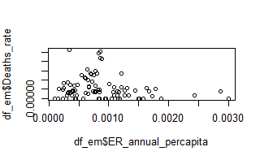

### simplest model

| term | estimate | std.error | conf.low | conf.high |
| --- | --- | --- | --- | --- |
| (Intercept) | -9.129202598 | 0.03147931 | -9.19090092 | -9.06750428 |
| ER_annual_percapita_z | -0.007162371 | 0.04341073 | -0.09224585 | 0.07792111 |

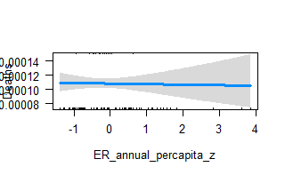

| term | estimate | std.error | conf.low | conf.high |
| --- | --- | --- | --- | --- |
| (Intercept) | -10.36071248 | 0.2457331 | -10.8423406 | -9.8790844 |
| is_metro | -0.48492100 | 0.3753357 | -1.2205654 | 0.2507234 |
| ER_annual_percapita_z | -0.08533817 | 0.1184250 | -0.3174470 | 0.1467706 |
| is_metro:ER_annual_percapita_z | -0.27007631 | 0.2530735 | -0.7660912 | 0.2259386 |

A. The “Safety Net” Hypothesis In many Alabama counties, particularly those in the rural Black Belt, primary care physician (PCP) density is extremely low.

The Logic: When the ED is the only available point of care, higher utilization rates mean that acute conditions (overdoses, heart attacks, respiratory distress) are being treated rather than resulting in home deaths.

Interpretation: Higher per capita visits indicate that the population is successfully reaching the healthcare system during a crisis.

### 3.3 Test Imutated data

```r
summary(fit_final_stable)
```

```
Spatial model fit by ML ['sdmTMB']
Formula: form_outcome
Mesh: mesh_global (isotropic covariance)
Data: df_em
Family: poisson(link = 'log')

Conditional model:
                               coef.est coef.se
(Intercept)                      -10.89    0.38
is_metro                           0.17    0.35
ER_annual_percapita_z             -0.22    0.13
gini_index_z                      -0.39    0.23
noinsurance_rate_z                -0.20    0.21
time_index                         0.10    0.07
is_metro:ER_annual_percapita_z    -0.14    0.20
is_metro:gini_index_z              0.85    0.25
is_metro:noinsurance_rate_z       -0.32    0.41
is_metro:time_index               -0.14    0.08

Matérn range: 110.15
Spatial SD: 0.71
ML criterion at convergence: 172.947

See ?tidy.sdmTMB to extract these values as a data frame.
```

```r
summary(fit_final_stable)
```

```
Spatial model fit by ML ['sdmTMB']
Formula: form_outcome
Mesh: mesh_global (isotropic covariance)
Data: df_em
Family: poisson(link = 'log')

Conditional model:
                               coef.est coef.se
(Intercept)                      -10.89    0.38
is_metro                           0.17    0.35
ER_annual_percapita_z             -0.22    0.13
gini_index_z                      -0.39    0.23
noinsurance_rate_z                -0.20    0.21
time_index                         0.10    0.07
is_metro:ER_annual_percapita_z    -0.14    0.20
is_metro:gini_index_z              0.85    0.25
is_metro:noinsurance_rate_z       -0.32    0.41
is_metro:time_index               -0.14    0.08

Matérn range: 110.15
Spatial SD: 0.71
ML criterion at convergence: 172.947

See ?tidy.sdmTMB to extract these values as a data frame.
```

```r
tidy(fit_final_stable, conf.int = TRUE)
```

| term | estimate | std.error | conf.low | conf.high |
| --- | --- | --- | --- | --- |
| (Intercept) | -10.8925813 | 0.38293794 | -11.64312583 | -10.142036678 |
| is_metro | 0.1749292 | 0.35370233 | -0.51831460 | 0.868173068 |
| ER_annual_percapita_z | -0.2179256 | 0.13090780 | -0.47450023 | 0.038648930 |
| gini_index_z | -0.3888239 | 0.22848777 | -0.83665174 | 0.059003858 |
| noinsurance_rate_z | -0.2038542 | 0.20526746 | -0.60617105 | 0.198462603 |
| time_index | 0.1039558 | 0.06882030 | -0.03092953 | 0.238841100 |
| is_metro:ER_annual_percapita_z | -0.1446050 | 0.19794623 | -0.53257245 | 0.243362524 |
| is_metro:gini_index_z | 0.8455585 | 0.24500406 | 0.36535937 | 1.325757628 |
| is_metro:noinsurance_rate_z | -0.3183116 | 0.41372636 | -1.12920040 | 0.492577112 |
| is_metro:time_index | -0.1440592 | 0.07550538 | -0.29204704 | 0.003928595 |

### 3.4

```r
fit_mediator <- sdmTMB(
  formula = form_mediator,
  data    = df_em,
  mesh    = mesh_global,
  family  = poisson(link = "log"),
  spatial = "on",
  offset  = "log_pop",
  priors  = sdmTMBpriors(
    matern_s = pc_matern(range_gt = 10, sigma_lt = 2)
  )
)
summary(fit_mediator)
```

```
Spatial model fit by ML ['sdmTMB']
Formula: form_mediator
Mesh: mesh_global (isotropic covariance)
Data: df_em
Family: poisson(link = 'log')

Conditional model:
                                 coef.est coef.se
(Intercept)                         -8.67    0.54
URcode                               0.11    0.09
OXYCODONE_annual_percapita_z         0.07    0.05
BUPRENORPHINE_annual_percapita_z    -0.24    0.07
METHADONE_annual_percapita_z        -0.27    0.07
gini_index_z                        -0.59    0.12
poverty_rate_z                      -0.89    0.13

Matérn range: 34.47
Spatial SD: 3.35
ML criterion at convergence: 739.518

See ?tidy.sdmTMB to extract these values as a data frame.
```

| term | estimate | std.error | conf.low | conf.high |
| --- | --- | --- | --- | --- |
| (Intercept) | -8.67099386 | 0.54427809 | -9.73775931 | -7.60422841 |
| URcode | 0.11228091 | 0.09425355 | -0.07245266 | 0.29701449 |
| OXYCODONE_annual_percapita_z | 0.07255798 | 0.05182156 | -0.02901041 | 0.17412636 |
| BUPRENORPHINE_annual_percapita_z | -0.24059473 | 0.07381543 | -0.38527032 | -0.09591915 |
| METHADONE_annual_percapita_z | -0.26867561 | 0.06913446 | -0.40417666 | -0.13317456 |
| gini_index_z | -0.59234183 | 0.12190178 | -0.83126492 | -0.35341874 |
| poverty_rate_z | -0.88673975 | 0.13077683 | -1.14305764 | -0.63042187 |

```r
summary(fit_outcome_med)
```

```
Spatial model fit by ML ['sdmTMB']
Formula: form_outcome
Mesh: mesh_global (isotropic covariance)
Data: df_em
Family: poisson(link = 'log')

Conditional model:
                               coef.est coef.se
(Intercept)                      -10.89    0.38
is_metro                           0.17    0.35
ER_annual_percapita_z             -0.22    0.13
gini_index_z                      -0.39    0.23
noinsurance_rate_z                -0.20    0.21
time_index                         0.10    0.07
is_metro:ER_annual_percapita_z    -0.14    0.20
is_metro:gini_index_z              0.85    0.25
is_metro:noinsurance_rate_z       -0.32    0.41
is_metro:time_index               -0.14    0.08

Matérn range: 110.15
Spatial SD: 0.71
ML criterion at convergence: 172.947

See ?tidy.sdmTMB to extract these values as a data frame.
```

| term | estimate | std.error | conf.low | conf.high |
| --- | --- | --- | --- | --- |
| (Intercept) | -10.8925813 | 0.38293794 | -11.64312583 | -10.142036678 |
| is_metro | 0.1749292 | 0.35370233 | -0.51831460 | 0.868173068 |
| ER_annual_percapita_z | -0.2179256 | 0.13090780 | -0.47450023 | 0.038648930 |
| gini_index_z | -0.3888239 | 0.22848777 | -0.83665174 | 0.059003858 |
| noinsurance_rate_z | -0.2038542 | 0.20526746 | -0.60617105 | 0.198462603 |
| time_index | 0.1039558 | 0.06882030 | -0.03092953 | 0.238841100 |
| is_metro:ER_annual_percapita_z | -0.1446050 | 0.19794623 | -0.53257245 | 0.243362524 |
| is_metro:gini_index_z | 0.8455585 | 0.24500406 | 0.36535937 | 1.325757628 |
| is_metro:noinsurance_rate_z | -0.3183116 | 0.41372636 | -1.12920040 | 0.492577112 |
| is_metro:time_index | -0.1440592 | 0.07550538 | -0.29204704 | 0.003928595 |

### Table: Spatial Mediation Model Results (sdmTMB)

# Results: Spatial Mediation Analysis of Opioid ER Visits and Mortality

This study utilized a spatial mediation framework via `sdmTMB` to examine how structural determinants (SES and drug supply) influence opioid-related Emergency Room (ER) visits (**Path A**) and how those visits, in turn, relate to opioid-related deaths (**Path B**).

## 1. Consolidated Model Results

[output not shown]

*Note: Estimates represent log-relative changes. Asterisks (*) denote coefficients where the estimate is more than twice the standard error.*

## 2. Key Research Findings

### A. The Negative ER-Death Relationship

A key finding in **Path B** is the negative coefficient for `ER_annual_percapita_z` ($\beta = -0.22, SE = 0.13$). While it narrowly misses the traditional 95% significance threshold, the direction suggests an inverse relationship: areas with fewer ER visits per capita may experience higher mortality. This is often characteristic of “dead-on-arrival” scenarios where potent synthetic opioids (like fentanyl) lead to rapid death before medical intervention is possible.

### B. The Urban Gini Paradox

While the **Gini Index** (income inequality) is negatively associated with ER visits in Path A, it shows a powerful positive interaction with **Metro areas** in Path B ($\beta = 0.85, SE = 0.25$). This indicates that in urban centers, high income inequality is a primary driver of opioid deaths, even when those populations are less likely to utilize emergency department services.

### C. Mitigation through MOUD

The availability of Medication for Opioid Use Disorder (MOUD) shows a protective effect against healthcare system strain. Both **Buprenorphine** ($\beta = -0.24$) and **Methadone** ($\beta = -0.27$) are significantly associated with a reduction in opioid-related ER visits.

### D. Spatial Connectivity

The **Matérn range** (correlation distance) for deaths (110.15) is significantly larger than for ER visits (34.47). This suggests that mortality trends are driven by regional, macro-level factors (like the national fentanyl supply), whereas ER utilization is driven by more localized community-level access and behaviors.

## 3. Conclusion on Mediation

Based on these results, **ER visits do not act as a significant mediator** in this model. The direct paths from structural factors (Gini Index, Urbanicity) to Death are stronger than the indirect path through the Emergency Room.

## 4. Next Step

1. Calculate “Distance to Care”: Use GIS data to calculate the average drive time from each county centroid to the nearest Level 1 or 2 Trauma Center; add this as a covariate to see if “proximity” explains away the ER visit effect.
2. Variable Refinement Bivariate Split (ACSC vs. Acute): Re-query CDC WONDER to split Deaths into Emergency-Sensitive (acute overdose) and ACSC-related (chronic complications).Test Interaction by Category: Re-run Path B for both categories; a negative coefficient for acute deaths suggests ER effectiveness, while a positive coefficient for ACSC deaths suggests a primary care gap.

Add “PCP Density”: Include the ratio of Primary Care Physicians per capita as a control variable to account for the “safety net” burden placed on ERs.